# Prediction Assignment

LM

7/30/2021

### Summary of Project

The datasets utilized in this project were generated from 6 individuals who utilzed exercise tracking devices while completing barbell lifts correctly and incorrectly in 5 different ways. Information about the dataat:http://web.archive.org/web/20161224072740/http:/groupware.les.inf.puc-rio.br/har. The data will be used to build a model to attempt to predict how the exercise was performed. The classifications include: exactly according to the specification (Class A), throwing the elbows to the front (Class B), lifting the dumbbell only halfway (Class C), lowering the dumbbell only halfway (Class D) and throwing the hips to the front (Class E)

#### Loading and cleaning the data

R packages utilized include tidyverse, caret, randomForest, janitor, e1071, and gtsummary. A seed of 500 was set to assure reproducibility. Cleaning the data consisted of the following steps: 1. removing columns with that contained only NA values, 2. removing metadata columns, and 3. removing highly correlated variables. The training dataset was also evaluated to determine if there were any near zero variance variables but there were none after completing the 3 steps.

Final cleaned datasets Training data:

```r
dim(train_sub)
```

```
## [1] 19622    40
```

Validation data

```r
dim(validate_final)
```

```
## [1] 20 39
```

#### Partioning the data and creating a Random Forest model

```r
inTrain <- createDataPartition(y = train_sub$classe, p = 0.6, list = FALSE)
training<- train_sub[inTrain,]
testing<- train_sub[-inTrain,]


mod_rf<- train(classe~.,
               data = training,
               method = "ranger",
               trControl = trainControl(method = "cv",
                                        number = 3,
                                        verboseIter = F))

predict_rf<- predict(mod_rf, newdata = testing)

confusionMatrix(predict_rf, testing$classe)
```

```
## Confusion Matrix and Statistics
##
##           Reference
## Prediction    A    B    C    D    E
##          A 2227    6    0    0    0
##          B    5 1501   14    0    1
##          C    0   10 1352   26    3
##          D    0    0    2 1259    2
##          E    0    1    0    1 1436
##
## Overall Statistics
##
##                Accuracy : 0.991
##                  95% CI : (0.9886, 0.9929)
##     No Information Rate : 0.2845
##     P-Value [Acc > NIR] : < 2.2e-16
##
##                   Kappa : 0.9886
##
##  Mcnemar's Test P-Value : NA
##
## Statistics by Class:
##
##                      Class: A Class: B Class: C Class: D Class: E
## Sensitivity            0.9978   0.9888   0.9883   0.9790   0.9958
## Specificity            0.9989   0.9968   0.9940   0.9994   0.9997
## Pos Pred Value         0.9973   0.9869   0.9720   0.9968   0.9986
## Neg Pred Value         0.9991   0.9973   0.9975   0.9959   0.9991
## Prevalence             0.2845   0.1935   0.1744   0.1639   0.1838
## Detection Rate         0.2838   0.1913   0.1723   0.1605   0.1830
## Detection Prevalence   0.2846   0.1939   0.1773   0.1610   0.1833
## Balanced Accuracy      0.9983   0.9928   0.9911   0.9892   0.9978
```

|  | **N = 20**<sup>1</sup> |
| --- | --- |
| Exercise class |  |
| A | 7 (35%) |
| B | 8 (40%) |
| C | 1 (5.0%) |
| D | 1 (5.0%) |
| E | 3 (15%) |

<sup>*1*</sup> n (%)

### Appendix

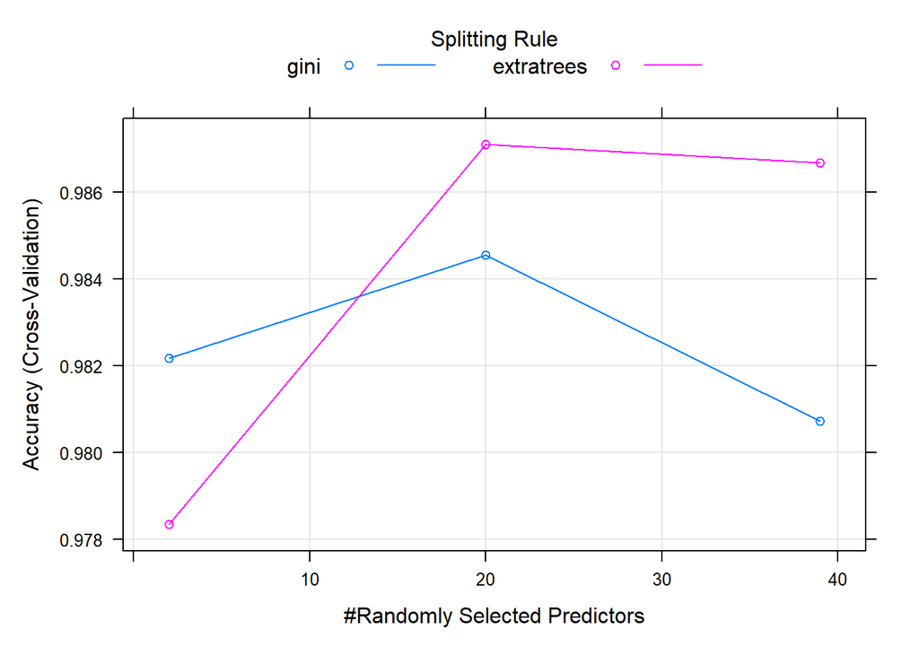